# R Notebook - Used Cars

# Exemplo rápido EDA

Importando os dados.

```r
data <- read.csv("./data/usedcars.csv")
```

Visão rápida e geral.

```r
str(data_usedCars)
```

```
'data.frame':   150 obs. of  6 variables:
 $ year        : int  2011 2011 2011 2011 2012 2010 2011 2010 2011 2010 ...
 $ model       : chr  "SEL" "SEL" "SEL" "SEL" ...
 $ price       : int  21992 20995 19995 17809 17500 17495 17000 16995 16995 16995 ...
 $ mileage     : int  7413 10926 7351 11613 8367 25125 27393 21026 32655 36116 ...
 $ color       : chr  "Yellow" "Gray" "Silver" "Gray" ...
 $ transmission: chr  "AUTO" "AUTO" "AUTO" "AUTO" ...
```

# Visão rápida dados Quantitativos

Sumário geral dos dados.

```r
print(summary(data_usedCars[c("price", "mileage")]))
```

```
     price          mileage
 Min.   : 3800   Min.   :  4867
 1st Qu.:10995   1st Qu.: 27200
 Median :13592   Median : 36385
 Mean   :12962   Mean   : 44261
 3rd Qu.:14904   3rd Qu.: 55124
 Max.   :21992   Max.   :151479
```

Range

```r
range(data_usedCars$price)
```

```
[1]  3800 21992
```

```r
print(paste("Range coluna price: ", diff(range(data_usedCars$price))))
```

```
[1] "Range coluna price:  18192"
```

Interquartile range (IQR), diferença entre Q1 e Q3.

```r
IQR(data_usedCars$price)
```

```
[1] 3909.5
```

Quantiles:

```r
quantile(data_usedCars$price)
```

```
     0%     25%     50%     75%    100%
 3800.0 10995.0 13591.5 14904.5 21992.0
```

```r
quantile(data_usedCars$price, probs = c(0.01, 0.25, 0.3)) # 1% dos dados estão até 5428.69, 25% estão até 10995.00 ...
```

```
      1%      25%      30%
 5428.69 10995.00 11982.80
```

```r
quantile(data_usedCars$price, seq(from = 0, to = 1, by=0.20))
```

```
     0%     20%     40%     60%     80%    100%
 3800.0 10759.4 12993.8 13992.0 14999.0 21992.0
```

Boxplots

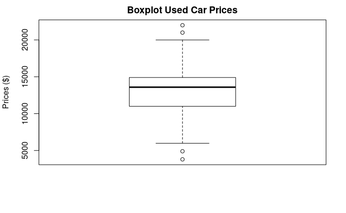

```r
boxplot(data_usedCars$price, main="Boxplot Used Car Prices", ylab="Prices ($)")
```

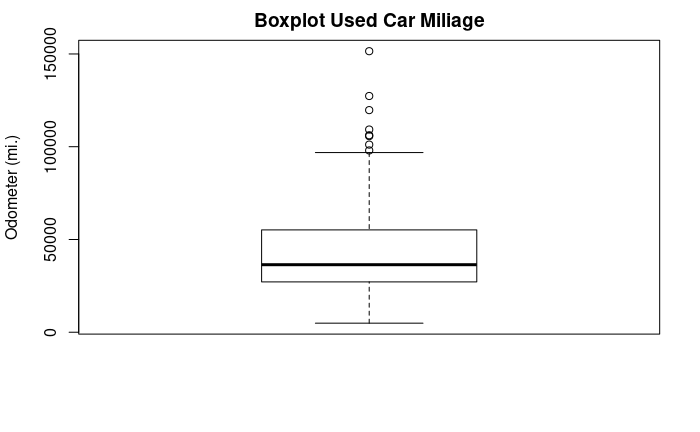

```r
boxplot(data_usedCars$mileage, main="Boxplot Used Car Miliage", ylab="Odometer (mi.)")
```

Histogramas.

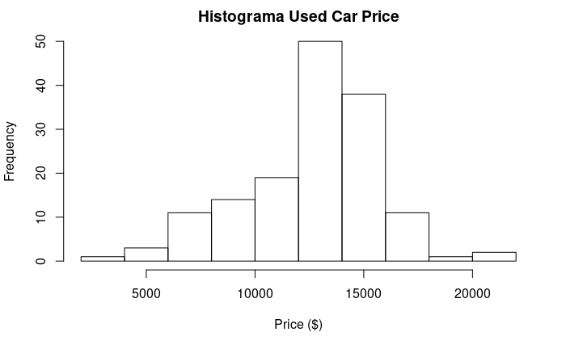

```r
hist(data_usedCars$price, main="Histograma Used Car Price", xlab="Price ($)")
```

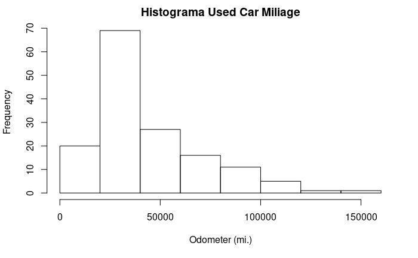

```r
hist(data_usedCars$mileage, main="Histograma Used Car Miliage", xlab="Odometer (mi.)")
```

Variância e desvio padrão.

```r
var(data_usedCars$price)
```

```
[1] 9749892
```

```r
sd(data_usedCars$price)
```

```
[1] 3122.482
```

# Visão geral dados Qualitativos

Tabela de contagem de valores.

```r
table(data_usedCars$year)
```

```
2000 2001 2002 2003 2004 2005 2006 2007 2008 2009 2010 2011 2012
   3    1    1    1    3    2    6   11   14   42   49   16    1
```

```r
table(data_usedCars$model)
```

```
 SE SEL SES
 78  23  49
```

```r
table(data_usedCars$color)
```

```
 Black   Blue   Gold   Gray  Green    Red Silver  White Yellow
    35     17      1     16      5     25     32     16      3
```

```r
table(data_usedCars$transmission)
```

```
  AUTO MANUAL
   128     22
```

Tabela de count values da coluna “year”.

```r
year_prc
```

```
2000 2001 2002 2003 2004 2005 2006 2007 2008 2009 2010 2011 2012
 2.0  0.7  0.7  0.7  2.0  1.3  4.0  7.3  9.3 28.0 32.7 10.7  0.7
```

Tabela de count values das outras colunas.

```r
round(prop.table(table(data_usedCars$model))*100, digits = 1)
```

```
  SE  SEL  SES
52.0 15.3 32.7
```

```r
round(prop.table(table(data_usedCars$color))*100, digits = 1)
```

```
 Black   Blue   Gold   Gray  Green    Red Silver  White Yellow
  23.3   11.3    0.7   10.7    3.3   16.7   21.3   10.7    2.0
```

```r
round(prop.table(table(data_usedCars$transmission))*100, digits = 1)
```

```
  AUTO MANUAL
  85.3   14.7
```

# Scatterplot de algumas variáveis

[figure not shown]

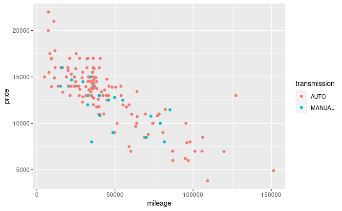

```r
library(ggplot2)
ggplot(data_usedCars, aes(x=mileage, y=price, color=transmission)) + geom_point()
```

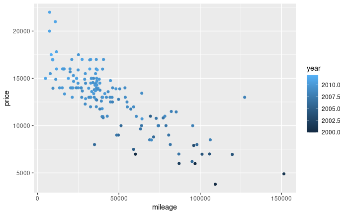

```r
ggplot(data_usedCars, aes(x=mileage, y=price, color=year)) + geom_point()
```

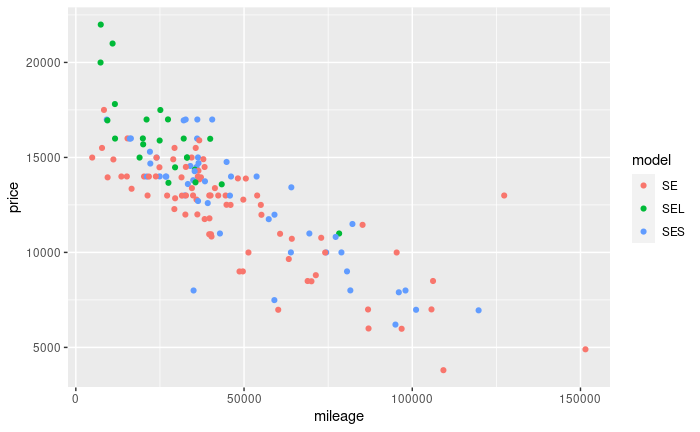

```r
ggplot(data_usedCars, aes(x=mileage, y=price, color=model)) + geom_point()
```

```r
#ggplot(data_usedCars, aes(x=mileage, y=price, color=conservative_color)) + geom_point()
```

É possível observar alguns pontos que já eram esperados: - Quanto maior a quilometrage (mileage) mais antigo (year) é o carro. Correlação negativa. - A transmissão não parece afetar o preço final do carro. - Os modelos SEL são os mais caros, novos e de menor quilômetragem.

# Examinando relação - two-way cross-tabulations

```r
install.packages("gmodels") #
```

Criando uma nova coluna “Conservative”, coluna binária que representa todas as cores dos veículos em duas categorias, Cores conservativas (preto, cinza, branco, prata) e o restante é classificada como não conservativa.

```r
str(data_usedCars)
```

```
'data.frame':   150 obs. of  7 variables:
 $ year              : int  2011 2011 2011 2011 2012 2010 2011 2010 2011 2010 ...
 $ model             : chr  "SEL" "SEL" "SEL" "SEL" ...
 $ price             : int  21992 20995 19995 17809 17500 17495 17000 16995 16995 16995 ...
 $ mileage           : int  7413 10926 7351 11613 8367 25125 27393 21026 32655 36116 ...
 $ color             : chr  "Yellow" "Gray" "Silver" "Gray" ...
 $ transmission      : chr  "AUTO" "AUTO" "AUTO" "AUTO" ...
 $ conservative_color: logi  FALSE TRUE TRUE TRUE TRUE TRUE ...
```

```r
CrossTable(x = data_usedCars$model, y = data_usedCars$conservative_color, chisq = TRUE)
```

```
   Cell Contents
|-------------------------|
|                       N |
| Chi-square contribution |
|           N / Row Total |
|           N / Col Total |
|         N / Table Total |
|-------------------------|


Total Observations in Table:  150


                    | data_usedCars$conservative_color
data_usedCars$model |     FALSE |      TRUE | Row Total |
--------------------|-----------|-----------|-----------|
                 SE |        27 |        51 |        78 |
                    |     0.009 |     0.004 |           |
                    |     0.346 |     0.654 |     0.520 |
                    |     0.529 |     0.515 |           |
                    |     0.180 |     0.340 |           |
--------------------|-----------|-----------|-----------|
                SEL |         7 |        16 |        23 |
                    |     0.086 |     0.044 |           |
                    |     0.304 |     0.696 |     0.153 |
                    |     0.137 |     0.162 |           |
                    |     0.047 |     0.107 |           |
--------------------|-----------|-----------|-----------|
                SES |        17 |        32 |        49 |
                    |     0.007 |     0.004 |           |
                    |     0.347 |     0.653 |     0.327 |
                    |     0.333 |     0.323 |           |
                    |     0.113 |     0.213 |           |
--------------------|-----------|-----------|-----------|
       Column Total |        51 |        99 |       150 |
                    |     0.340 |     0.660 |           |
--------------------|-----------|-----------|-----------|


Statistics for All Table Factors


Pearson's Chi-squared test
------------------------------------------------------------
Chi^2 =  0.1539564     d.f. =  2     p =  0.92591
```

# References

[1] Capítilo 2, livro: Machine Learning R, Brett Lantz [2]http://www.sthda.com/english/wiki/ggplot2-scatter-plots-quick-start-guide-r-software-and-data-visualization